# Project4_survival_analysis

## Reading data and EDA analysis

Reading “ovarian” data from “survival” packages. Structure of this data frame:

```r
data_survival <- data.frame(ovarian)
str(data_survival)
```

```
## 'data.frame':    26 obs. of  6 variables:
##  $ futime  : num  59 115 156 421 431 448 464 475 477 563 ...
##  $ fustat  : num  1 1 1 0 1 0 1 1 0 1 ...
##  $ age     : num  72.3 74.5 66.5 53.4 50.3 ...
##  $ resid.ds: num  2 2 2 2 2 1 2 2 2 1 ...
##  $ rx      : num  1 1 1 2 1 1 2 2 1 2 ...
##  $ ecog.ps : num  1 1 2 1 1 2 2 2 1 2 ...
```

Discription: -futime: survival or censoring time -fustat: censoring status -age: in years -resid.ds: residual disease present (1=no,2=yes) -rx: treatment group -ecog.ps: ECOG performance status (1 is better, see reference)

```r
head(data_survival)
```

```
##   futime fustat     age resid.ds rx ecog.ps
## 1     59      1 72.3315        2  1       1
## 2    115      1 74.4932        2  1       1
## 3    156      1 66.4658        2  1       2
## 4    421      0 53.3644        2  2       1
## 5    431      1 50.3397        2  1       1
## 6    448      0 56.4301        1  1       2
```

Let’s check NA values:

```r
colSums(is.na(data_survival))
```

```
##   futime   fustat      age resid.ds       rx  ecog.ps
##        0        0        0        0        0        0
```

There are no NA values.

Let’s check outliers (Picture 1):

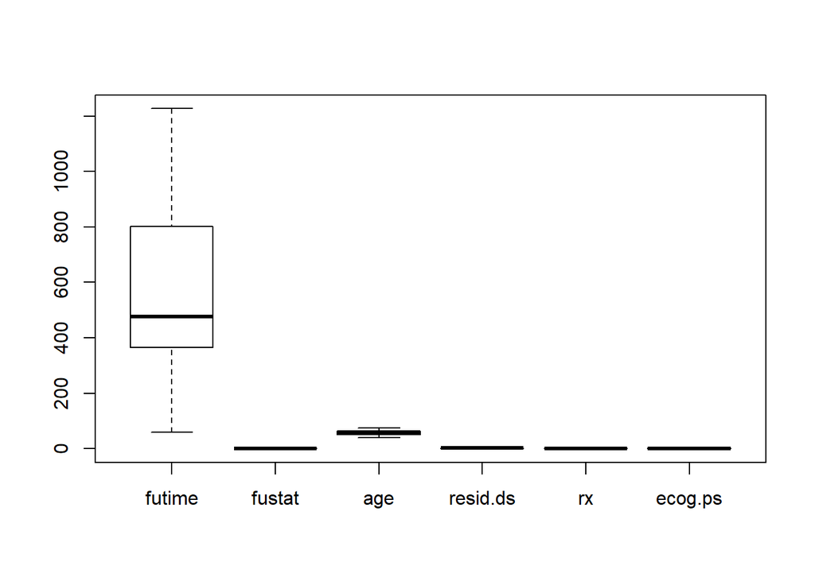

```r
boxplot(data_survival)
```

There are no outliers.

change some variables to factor.

```r
data_survival$resid.ds <- factor(data_survival$resid.ds, levels = c(1,2), labels = c("No", "Yes"))
data_survival$rx <- factor(data_survival$rx, levels = c(1,2), labels = c("Trial_1", "Trial_2"))
data_survival$ecog.ps <- factor(data_survival$ecog.ps, levels = c(1,2), labels = c("Good", "No_good"))
```

Histogram of “age”:

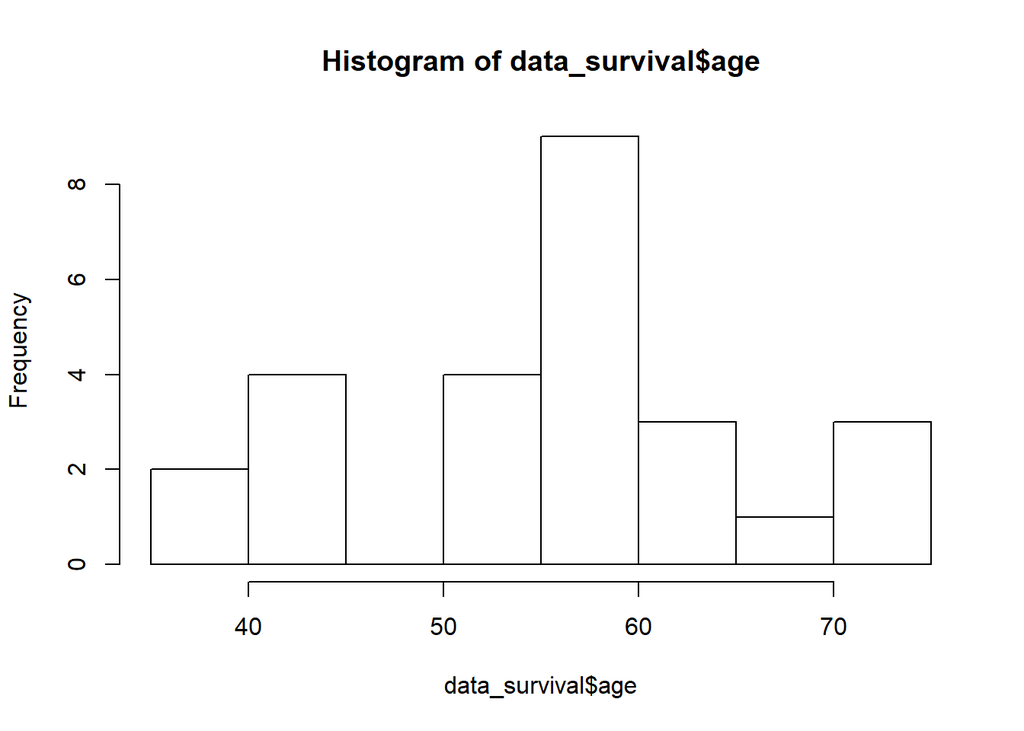

```r
hist(data_survival$age)
```

```r
data_survival <- data_survival %>% mutate(age_groups = ifelse(age >= 60, "Group_1", "Group_2"))
data_survival$age_groups <- factor(data_survival$age_groups)
```

Let’s see data structure again:

```r
str(data_survival)
```

```
## 'data.frame':    26 obs. of  7 variables:
##  $ futime    : num  59 115 156 421 431 448 464 475 477 563 ...
##  $ fustat    : num  1 1 1 0 1 0 1 1 0 1 ...
##  $ age       : num  72.3 74.5 66.5 53.4 50.3 ...
##  $ resid.ds  : Factor w/ 2 levels "No","Yes": 2 2 2 2 2 1 2 2 2 1 ...
##  $ rx        : Factor w/ 2 levels "Trial_1","Trial_2": 1 1 1 2 1 1 2 2 1 2 ...
##  $ ecog.ps   : Factor w/ 2 levels "Good","No_good": 1 1 2 1 1 2 2 2 1 2 ...
##  $ age_groups: Factor w/ 2 levels "Group_1","Group_2": 1 1 1 2 2 2 2 2 1 2 ...
```

## Kaplan Meier Survival Curves

Survival timeline:

```r
km <- with(data_survival, Surv(futime, fustat))
km
```

```
##  [1]   59   115   156   421+  431   448+  464   475   477+  563   638   744+
## [13]  769+  770+  803+  855+ 1040+ 1106+ 1129+ 1206+ 1227+  268   329   353
## [25]  365   377+
```

```r
km_fit <- survfit(Surv(futime, fustat) ~ 1, data=data_survival)
summary(km_fit, times = c(1,30,60,90*(1:10)))
```

```
## Call: survfit(formula = Surv(futime, fustat) ~ 1, data = data_survival)
##
##  time n.risk n.event survival std.err lower 95% CI upper 95% CI
##     1     26       0    1.000  0.0000        1.000        1.000
##    30     26       0    1.000  0.0000        1.000        1.000
##    60     25       1    0.962  0.0377        0.890        1.000
##    90     25       0    0.962  0.0377        0.890        1.000
##   180     23       2    0.885  0.0627        0.770        1.000
##   270     22       1    0.846  0.0708        0.718        0.997
##   360     20       2    0.769  0.0826        0.623        0.949
##   450     15       2    0.688  0.0919        0.529        0.894
##   540     12       2    0.596  0.0999        0.429        0.828
##   630     11       1    0.546  0.1032        0.377        0.791
##   720     10       1    0.497  0.1051        0.328        0.752
##   810      6       0    0.497  0.1051        0.328        0.752
##   900      5       0    0.497  0.1051        0.328        0.752
```

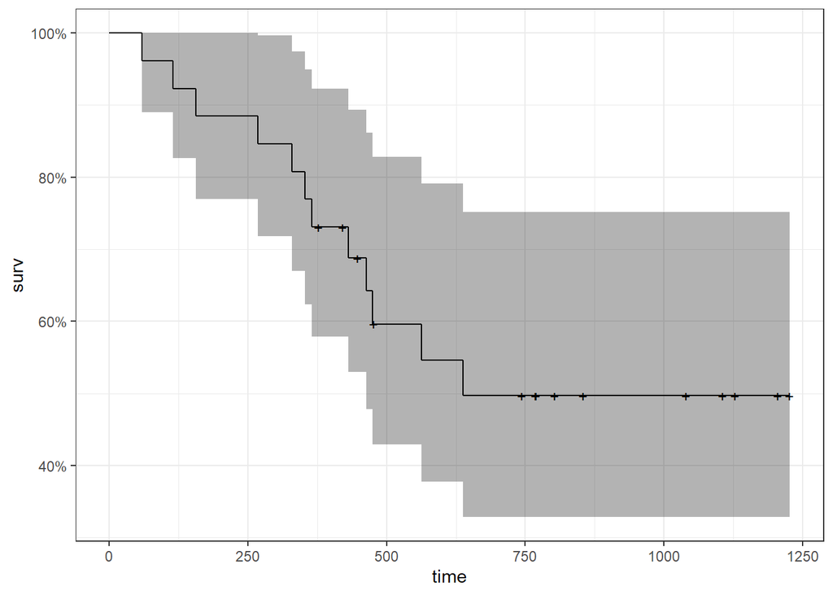

```r
autoplot(km_fit)
```

*Picture 2* Model of survival over time.

- Model of dependency of survival by the treatment group (Picture 2):

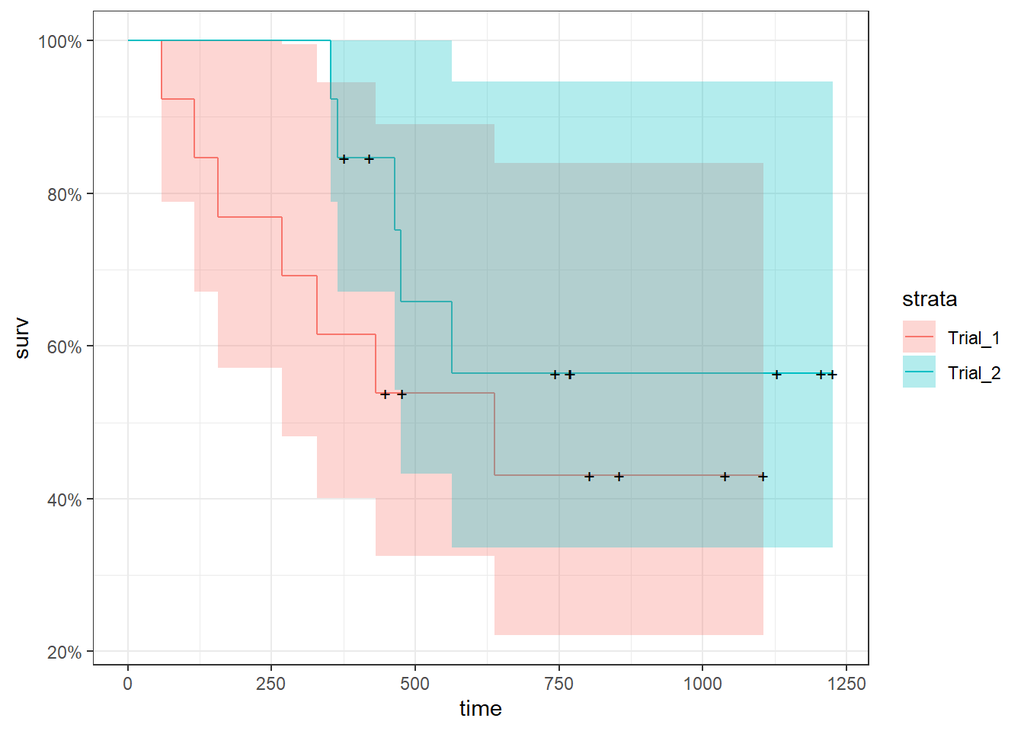

```r
km_trt_fit <- survfit(Surv(futime, fustat) ~ rx, data=data_survival)
autoplot(km_trt_fit)
```

*Picture 2* Model of dependency of survival by the treatment group.

- survival by the age group (Picture 3):

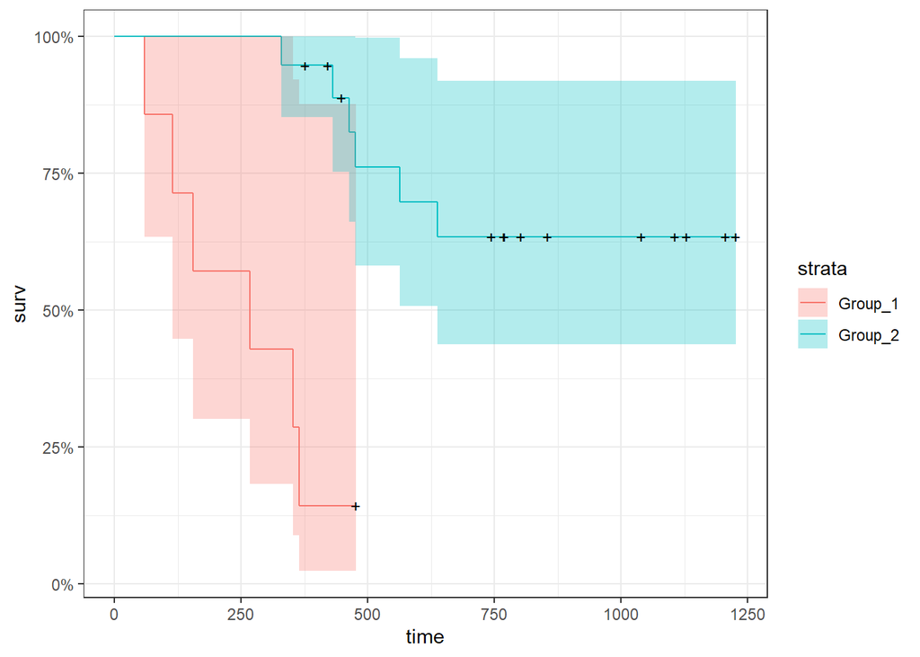

```r
km_age_fit <- survfit(Surv(futime, fustat) ~ age_groups, data=data_survival)
autoplot(km_age_fit)
```

*Picture 3* Survival by the age group.

- survival by the resid.ds group (Picture 4):

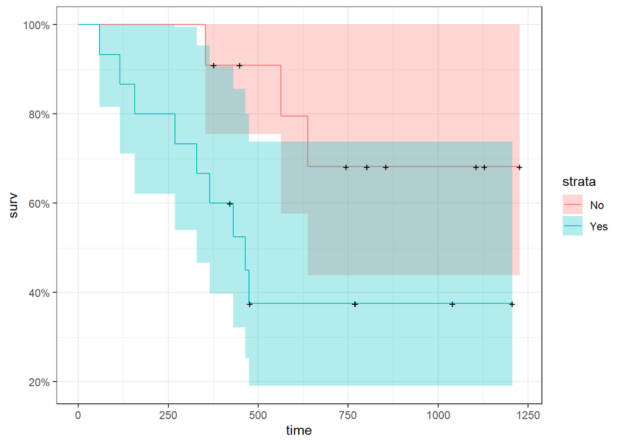

```r
km_resid_fit <- survfit(Surv(futime, fustat) ~ resid.ds, data=data_survival)
autoplot(km_resid_fit)
```

*Picture 4* Survival by the resid.ds group.

- survival by the ecog.ps group (Picture 5):

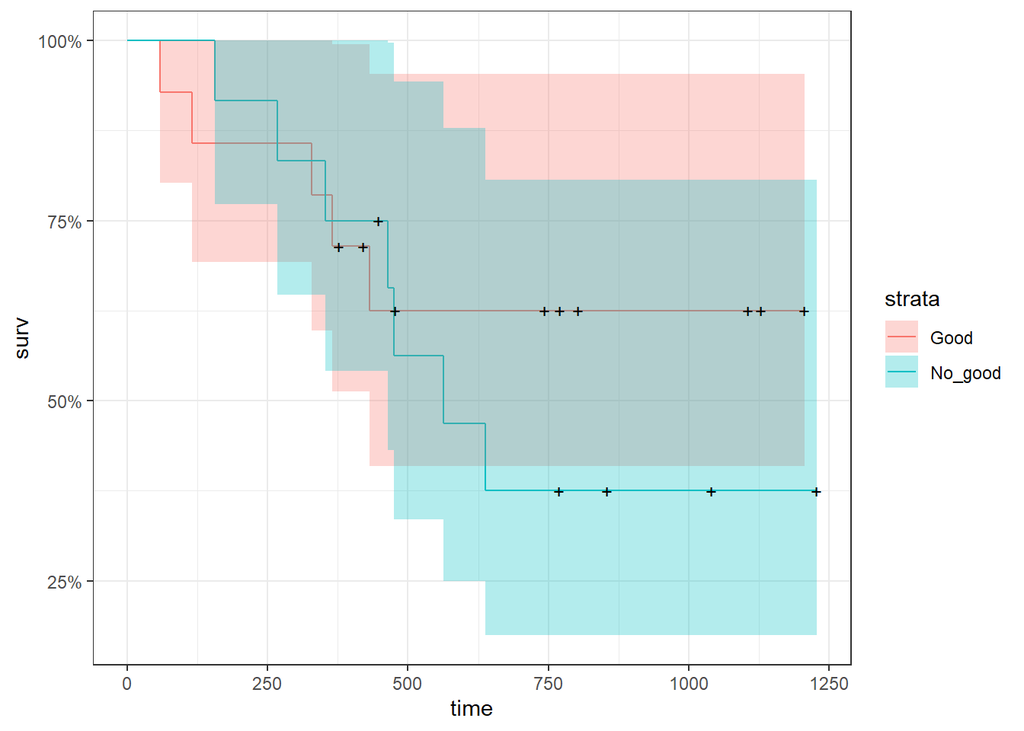

```r
km_ecog_fit <- survfit(Surv(futime, fustat) ~ ecog.ps, data=data_survival)
autoplot(km_ecog_fit)
```

*Picture 5* Survival by the ecog.ps group

## Sirvival statistics

1. “rx” group

```r
survdiff(Surv(futime, fustat) ~ rx, data = data_survival)
```

```
## Call:
## survdiff(formula = Surv(futime, fustat) ~ rx, data = data_survival)
##
##             N Observed Expected (O-E)^2/E (O-E)^2/V
## rx=Trial_1 13        7     5.23     0.596      1.06
## rx=Trial_2 13        5     6.77     0.461      1.06
##
##  Chisq= 1.1  on 1 degrees of freedom, p= 0.3
```

```r
data_survival$rx <- as.factor(data_survival$rx)
logrank_test(Surv(futime, fustat) ~ rx, data_survival)
```

```
##
##  Asymptotic Two-Sample Logrank Test
##
## data:  Surv(futime, fustat) by rx (Trial_1, Trial_2)
## Z = -1.0296, p-value = 0.3032
## alternative hypothesis: true theta is not equal to 1
```

The p-value is greater than 0.05, therefore, we cannot reject the null hypothesis that the survival rates for two different groups are the same.

2. “resid.ds” group

```r
survdiff(Surv(futime, fustat) ~ resid.ds, data = data_survival)
```

```
## Call:
## survdiff(formula = Surv(futime, fustat) ~ resid.ds, data = data_survival)
##
##               N Observed Expected (O-E)^2/E (O-E)^2/V
## resid.ds=No  11        3     6.26      1.70      3.62
## resid.ds=Yes 15        9     5.74      1.85      3.62
##
##  Chisq= 3.6  on 1 degrees of freedom, p= 0.06
```

```r
data_survival$resid.ds <- as.factor(data_survival$resid.ds)
logrank_test(Surv(futime, fustat) ~ resid.ds, data_survival)
```

```
##
##  Asymptotic Two-Sample Logrank Test
##
## data:  Surv(futime, fustat) by resid.ds (No, Yes)
## Z = 1.9234, p-value = 0.05444
## alternative hypothesis: true theta is not equal to 1
```

The p-value is greater than 0.05 too.

3. “ecog.ps” group

```r
survdiff(Surv(futime, fustat) ~ ecog.ps, data = data_survival)
```

```
## Call:
## survdiff(formula = Surv(futime, fustat) ~ ecog.ps, data = data_survival)
##
##                  N Observed Expected (O-E)^2/E (O-E)^2/V
## ecog.ps=Good    14        5     6.18     0.226     0.468
## ecog.ps=No_good 12        7     5.82     0.240     0.468
##
##  Chisq= 0.5  on 1 degrees of freedom, p= 0.5
```

```r
data_survival$ecog.ps <- as.factor(data_survival$ecog.ps)
logrank_test(Surv(futime, fustat) ~ ecog.ps, data_survival)
```

```
##
##  Asymptotic Two-Sample Logrank Test
##
## data:  Surv(futime, fustat) by ecog.ps (Good, No_good)
## Z = 0.69106, p-value = 0.4895
## alternative hypothesis: true theta is not equal to 1
```

The p-value is greater than 0.05 too.

4. “age” group

```r
survdiff(Surv(futime, fustat) ~ age_groups, data = data_survival)
```

```
## Call:
## survdiff(formula = Surv(futime, fustat) ~ age_groups, data = data_survival)
##
##                     N Observed Expected (O-E)^2/E (O-E)^2/V
## age_groups=Group_1  7        6     1.47     14.00      17.1
## age_groups=Group_2 19        6    10.53      1.95      17.1
##
##  Chisq= 17.1  on 1 degrees of freedom, p= 4e-05
```

```r
data_survival$age_groups <- as.factor(data_survival$age_groups)
logrank_test(Surv(futime, fustat) ~ age_groups, data_survival)
```

```
##
##  Asymptotic Two-Sample Logrank Test
##
## data:  Surv(futime, fustat) by age_groups (Group_1, Group_2)
## Z = -2.9778, p-value = 0.002903
## alternative hypothesis: true theta is not equal to 1
```

The p-value is less than 0.05. It means that “age” significantly affects survival.

## Risk factors analisys

Cox model:

```r
cox <- coxph(Surv(futime, fustat) ~ age_groups + resid.ds + rx + ecog.ps , data = data_survival)
summary(cox)
```

```
## Call:
## coxph(formula = Surv(futime, fustat) ~ age_groups + resid.ds +
##     rx + ecog.ps, data = data_survival)
##
##   n= 26, number of events= 12
##
##                       coef exp(coef) se(coef)      z Pr(>|z|)
## age_groupsGroup_2 -2.32085   0.09819  0.78695 -2.949  0.00319 **
## resid.dsYes        0.90019   2.46007  0.71892  1.252  0.21052
## rxTrial_2         -0.22147   0.80134  0.63202 -0.350  0.72603
## ecog.psNo_good     0.97998   2.66439  0.66945  1.464  0.14323
## ---
## Signif. codes:  0 '***' 0.001 '**' 0.01 '*' 0.05 '.' 0.1 ' ' 1
##
##                   exp(coef) exp(-coef) lower .95 upper .95
## age_groupsGroup_2   0.09819    10.1843    0.0210    0.4591
## resid.dsYes         2.46007     0.4065    0.6012   10.0668
## rxTrial_2           0.80134     1.2479    0.2322    2.7657
## ecog.psNo_good      2.66439     0.3753    0.7174    9.8954
##
## Concordance= 0.821  (se = 0.06 )
## Likelihood ratio test= 15.07  on 4 df,   p=0.005
## Wald test            = 13.18  on 4 df,   p=0.01
## Score (logrank) test = 19.56  on 4 df,   p=6e-04
```

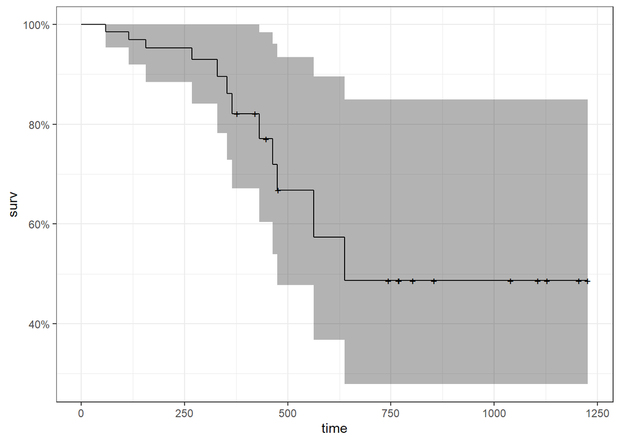

```r
cox_fit <- survfit(cox)
autoplot(cox_fit)
```

*Picture 6* Cox model

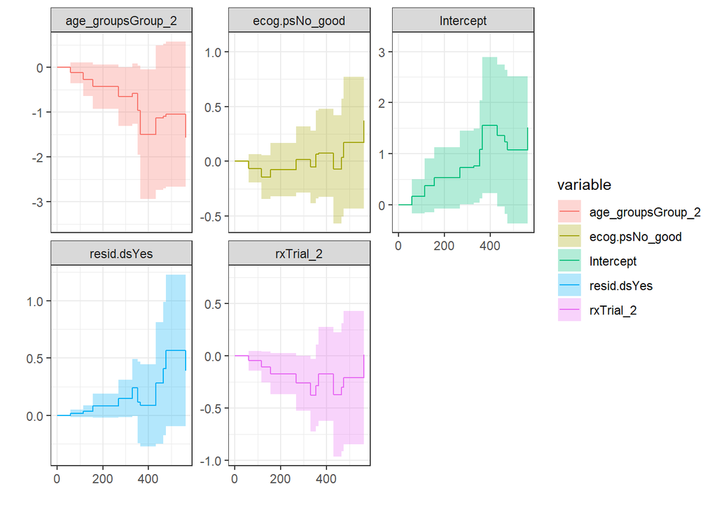

```r
aa_fit <- aareg(Surv(futime, fustat) ~ age_groups + resid.ds + rx + ecog.ps, data = data_survival)
autoplot(aa_fit)
```

*Picture 7* Analysis of covariance

There is no significant factors which affect to survival, except “age” (less then 60 years). And having no residual diseases and second type of treatment may affect to patient survival.

Hazard Ratio

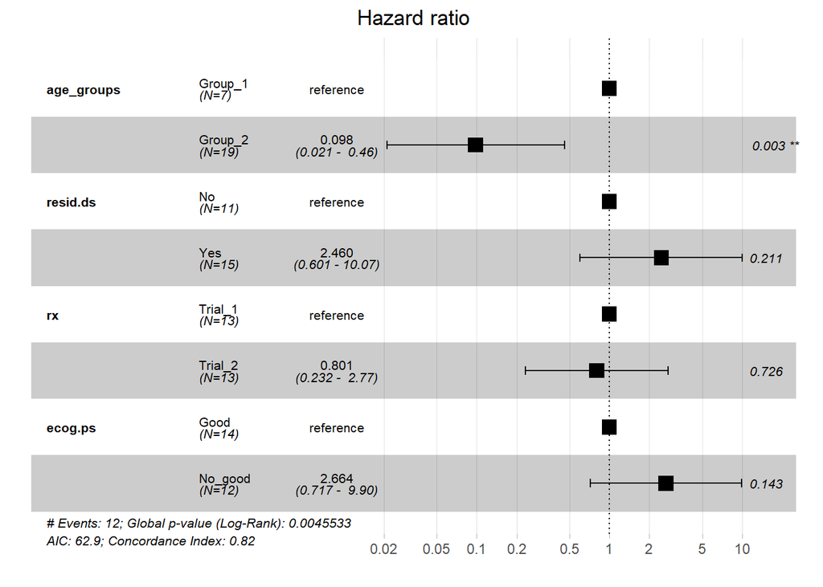

```r
fit.coxph <- coxph(Surv(futime, fustat) ~ age_groups + resid.ds + rx + ecog.ps, data = data_survival)
ggforest(fit.coxph, data = data_survival)
```

*Picture 8* Hazard ratio

Conclusion: only “age” factor significantly affects survival.